# Risk Factor Analysis

## Outcome Variable

**Outcome Variable:** wast_rec90d

## Predictor Variables

**Intervention Variable:** birthlen

**Adjustment Set:**

- arm
- sex
- W_mage
- meducyrs
- feducyrs
- vagbrth
- single
- brthmon
- W_parity
- delta_W_mage
- delta_meducyrs
- delta_feducyrs
- delta_vagbrth
- delta_single
- delta_brthmon
- delta_W_parity

## Stratifying Variables

The analysis was stratified on these variable(s):

- agecat
- studyid
- country

## Data Summary

| agecat | studyid | country | birthlen | wast_rec90d | n_cell | n |
| --- | --- | --- | --- | --- | --- | --- |
| 0-24 months | ki0047075b-MAL-ED | BANGLADESH | >=50 cm | 0 | 6 | 113 |
| 0-24 months | ki0047075b-MAL-ED | BANGLADESH | >=50 cm | 1 | 12 | 113 |
| 0-24 months | ki0047075b-MAL-ED | BANGLADESH | <48 cm | 0 | 21 | 113 |
| 0-24 months | ki0047075b-MAL-ED | BANGLADESH | <48 cm | 1 | 39 | 113 |
| 0-24 months | ki0047075b-MAL-ED | BANGLADESH | [48-50) cm | 0 | 14 | 113 |
| 0-24 months | ki0047075b-MAL-ED | BANGLADESH | [48-50) cm | 1 | 21 | 113 |
| 0-24 months | ki0047075b-MAL-ED | BRAZIL | >=50 cm | 0 | 0 | 8 |
| 0-24 months | ki0047075b-MAL-ED | BRAZIL | >=50 cm | 1 | 1 | 8 |
| 0-24 months | ki0047075b-MAL-ED | BRAZIL | <48 cm | 0 | 1 | 8 |
| 0-24 months | ki0047075b-MAL-ED | BRAZIL | <48 cm | 1 | 3 | 8 |
| 0-24 months | ki0047075b-MAL-ED | BRAZIL | [48-50) cm | 0 | 1 | 8 |
| 0-24 months | ki0047075b-MAL-ED | BRAZIL | [48-50) cm | 1 | 2 | 8 |
| 0-24 months | ki0047075b-MAL-ED | INDIA | >=50 cm | 0 | 1 | 40 |
| 0-24 months | ki0047075b-MAL-ED | INDIA | >=50 cm | 1 | 4 | 40 |
| 0-24 months | ki0047075b-MAL-ED | INDIA | <48 cm | 0 | 8 | 40 |
| 0-24 months | ki0047075b-MAL-ED | INDIA | <48 cm | 1 | 12 | 40 |
| 0-24 months | ki0047075b-MAL-ED | INDIA | [48-50) cm | 0 | 6 | 40 |
| 0-24 months | ki0047075b-MAL-ED | INDIA | [48-50) cm | 1 | 9 | 40 |
| 0-24 months | ki0047075b-MAL-ED | NEPAL | >=50 cm | 0 | 1 | 13 |
| 0-24 months | ki0047075b-MAL-ED | NEPAL | >=50 cm | 1 | 2 | 13 |
| 0-24 months | ki0047075b-MAL-ED | NEPAL | <48 cm | 0 | 1 | 13 |
| 0-24 months | ki0047075b-MAL-ED | NEPAL | <48 cm | 1 | 6 | 13 |
| 0-24 months | ki0047075b-MAL-ED | NEPAL | [48-50) cm | 0 | 0 | 13 |
| 0-24 months | ki0047075b-MAL-ED | NEPAL | [48-50) cm | 1 | 3 | 13 |
| 0-24 months | ki0047075b-MAL-ED | PERU | >=50 cm | 0 | 0 | 32 |
| 0-24 months | ki0047075b-MAL-ED | PERU | >=50 cm | 1 | 6 | 32 |
| 0-24 months | ki0047075b-MAL-ED | PERU | <48 cm | 0 | 4 | 32 |
| 0-24 months | ki0047075b-MAL-ED | PERU | <48 cm | 1 | 13 | 32 |
| 0-24 months | ki0047075b-MAL-ED | PERU | [48-50) cm | 0 | 1 | 32 |
| 0-24 months | ki0047075b-MAL-ED | PERU | [48-50) cm | 1 | 8 | 32 |

[output cut: 420 more lines]

The following strata were considered:

- agecat: 0-24 months, studyid: ki0047075b-MAL-ED, country: BANGLADESH
- agecat: 0-24 months, studyid: ki0047075b-MAL-ED, country: BRAZIL
- agecat: 0-24 months, studyid: ki0047075b-MAL-ED, country: INDIA
- agecat: 0-24 months, studyid: ki0047075b-MAL-ED, country: NEPAL
- agecat: 0-24 months, studyid: ki0047075b-MAL-ED, country: PERU
- agecat: 0-24 months, studyid: ki0047075b-MAL-ED, country: SOUTH AFRICA
- agecat: 0-24 months, studyid: ki0047075b-MAL-ED, country: TANZANIA, UNITED REPUBLIC OF
- agecat: 0-24 months, studyid: ki1000108-CMC-V-BCS-2002, country: INDIA
- agecat: 0-24 months, studyid: ki1000108-IRC, country: INDIA
- agecat: 0-24 months, studyid: ki1000109-EE, country: PAKISTAN
- agecat: 0-24 months, studyid: ki1000109-ResPak, country: PAKISTAN
- agecat: 0-24 months, studyid: ki1000304b-SAS-CompFeed, country: INDIA
- agecat: 0-24 months, studyid: ki1017093-NIH-Birth, country: BANGLADESH
- agecat: 0-24 months, studyid: ki1017093b-PROVIDE, country: BANGLADESH
- agecat: 0-24 months, studyid: ki1017093c-NIH-Crypto, country: BANGLADESH
- agecat: 0-24 months, studyid: ki1101329-Keneba, country: GAMBIA
- agecat: 0-24 months, studyid: ki1113344-GMS-Nepal, country: NEPAL
- agecat: 0-24 months, studyid: ki1114097-CMIN, country: BANGLADESH
- agecat: 0-24 months, studyid: ki1119695-PROBIT, country: BELARUS
- agecat: 0-24 months, studyid: ki1126311-ZVITAMBO, country: ZIMBABWE
- agecat: 0-24 months, studyid: ki1135781-COHORTS, country: GUATEMALA
- agecat: 0-24 months, studyid: ki1135781-COHORTS, country: INDIA
- agecat: 0-24 months, studyid: ki1135781-COHORTS, country: PHILIPPINES
- agecat: 0-24 months, studyid: kiGH5241-JiVitA-3, country: BANGLADESH
- agecat: 0-24 months, studyid: kiGH5241-JiVitA-4, country: BANGLADESH
- agecat: 0-6 months, studyid: ki0047075b-MAL-ED, country: BANGLADESH
- agecat: 0-6 months, studyid: ki0047075b-MAL-ED, country: BRAZIL
- agecat: 0-6 months, studyid: ki0047075b-MAL-ED, country: INDIA
- agecat: 0-6 months, studyid: ki0047075b-MAL-ED, country: NEPAL
- agecat: 0-6 months, studyid: ki0047075b-MAL-ED, country: PERU
- agecat: 0-6 months, studyid: ki0047075b-MAL-ED, country: SOUTH AFRICA
- agecat: 0-6 months, studyid: ki0047075b-MAL-ED, country: TANZANIA, UNITED REPUBLIC OF
- agecat: 0-6 months, studyid: ki1000108-CMC-V-BCS-2002, country: INDIA
- agecat: 0-6 months, studyid: ki1000108-IRC, country: INDIA
- agecat: 0-6 months, studyid: ki1000109-EE, country: PAKISTAN
- agecat: 0-6 months, studyid: ki1000109-ResPak, country: PAKISTAN
- agecat: 0-6 months, studyid: ki1000304b-SAS-CompFeed, country: INDIA
- agecat: 0-6 months, studyid: ki1017093-NIH-Birth, country: BANGLADESH
- agecat: 0-6 months, studyid: ki1017093b-PROVIDE, country: BANGLADESH
- agecat: 0-6 months, studyid: ki1017093c-NIH-Crypto, country: BANGLADESH
- agecat: 0-6 months, studyid: ki1101329-Keneba, country: GAMBIA
- agecat: 0-6 months, studyid: ki1113344-GMS-Nepal, country: NEPAL
- agecat: 0-6 months, studyid: ki1114097-CMIN, country: BANGLADESH
- agecat: 0-6 months, studyid: ki1119695-PROBIT, country: BELARUS
- agecat: 0-6 months, studyid: ki1126311-ZVITAMBO, country: ZIMBABWE
- agecat: 0-6 months, studyid: ki1135781-COHORTS, country: GUATEMALA
- agecat: 0-6 months, studyid: ki1135781-COHORTS, country: INDIA
- agecat: 0-6 months, studyid: ki1135781-COHORTS, country: PHILIPPINES
- agecat: 0-6 months, studyid: kiGH5241-JiVitA-3, country: BANGLADESH
- agecat: 0-6 months, studyid: kiGH5241-JiVitA-4, country: BANGLADESH
- agecat: 6-24 months, studyid: ki0047075b-MAL-ED, country: BANGLADESH
- agecat: 6-24 months, studyid: ki0047075b-MAL-ED, country: BRAZIL
- agecat: 6-24 months, studyid: ki0047075b-MAL-ED, country: INDIA
- agecat: 6-24 months, studyid: ki0047075b-MAL-ED, country: NEPAL
- agecat: 6-24 months, studyid: ki0047075b-MAL-ED, country: PERU
- agecat: 6-24 months, studyid: ki0047075b-MAL-ED, country: SOUTH AFRICA
- agecat: 6-24 months, studyid: ki0047075b-MAL-ED, country: TANZANIA, UNITED REPUBLIC OF
- agecat: 6-24 months, studyid: ki1000108-CMC-V-BCS-2002, country: INDIA
- agecat: 6-24 months, studyid: ki1000108-IRC, country: INDIA
- agecat: 6-24 months, studyid: ki1000109-EE, country: PAKISTAN
- agecat: 6-24 months, studyid: ki1000109-ResPak, country: PAKISTAN
- agecat: 6-24 months, studyid: ki1000304b-SAS-CompFeed, country: INDIA
- agecat: 6-24 months, studyid: ki1017093-NIH-Birth, country: BANGLADESH
- agecat: 6-24 months, studyid: ki1017093b-PROVIDE, country: BANGLADESH
- agecat: 6-24 months, studyid: ki1017093c-NIH-Crypto, country: BANGLADESH
- agecat: 6-24 months, studyid: ki1101329-Keneba, country: GAMBIA
- agecat: 6-24 months, studyid: ki1113344-GMS-Nepal, country: NEPAL
- agecat: 6-24 months, studyid: ki1114097-CMIN, country: BANGLADESH
- agecat: 6-24 months, studyid: ki1119695-PROBIT, country: BELARUS
- agecat: 6-24 months, studyid: ki1126311-ZVITAMBO, country: ZIMBABWE
- agecat: 6-24 months, studyid: ki1135781-COHORTS, country: GUATEMALA
- agecat: 6-24 months, studyid: ki1135781-COHORTS, country: INDIA
- agecat: 6-24 months, studyid: ki1135781-COHORTS, country: PHILIPPINES
- agecat: 6-24 months, studyid: kiGH5241-JiVitA-3, country: BANGLADESH
- agecat: 6-24 months, studyid: kiGH5241-JiVitA-4, country: BANGLADESH

### Dropped Strata

Some strata were dropped due to rare outcomes:

- agecat: 0-24 months, studyid: ki0047075b-MAL-ED, country: BRAZIL
- agecat: 0-24 months, studyid: ki0047075b-MAL-ED, country: INDIA
- agecat: 0-24 months, studyid: ki0047075b-MAL-ED, country: NEPAL
- agecat: 0-24 months, studyid: ki0047075b-MAL-ED, country: PERU
- agecat: 0-24 months, studyid: ki0047075b-MAL-ED, country: SOUTH AFRICA
- agecat: 0-24 months, studyid: ki0047075b-MAL-ED, country: TANZANIA, UNITED REPUBLIC OF
- agecat: 0-24 months, studyid: ki1000108-CMC-V-BCS-2002, country: INDIA
- agecat: 0-24 months, studyid: ki1000109-ResPak, country: PAKISTAN
- agecat: 0-24 months, studyid: ki1114097-CMIN, country: BANGLADESH
- agecat: 0-6 months, studyid: ki0047075b-MAL-ED, country: BANGLADESH
- agecat: 0-6 months, studyid: ki0047075b-MAL-ED, country: BRAZIL
- agecat: 0-6 months, studyid: ki0047075b-MAL-ED, country: INDIA
- agecat: 0-6 months, studyid: ki0047075b-MAL-ED, country: NEPAL
- agecat: 0-6 months, studyid: ki0047075b-MAL-ED, country: PERU
- agecat: 0-6 months, studyid: ki0047075b-MAL-ED, country: SOUTH AFRICA
- agecat: 0-6 months, studyid: ki0047075b-MAL-ED, country: TANZANIA, UNITED REPUBLIC OF
- agecat: 0-6 months, studyid: ki1000108-CMC-V-BCS-2002, country: INDIA
- agecat: 0-6 months, studyid: ki1000109-EE, country: PAKISTAN
- agecat: 0-6 months, studyid: ki1000109-ResPak, country: PAKISTAN
- agecat: 0-6 months, studyid: ki1017093c-NIH-Crypto, country: BANGLADESH
- agecat: 0-6 months, studyid: ki1114097-CMIN, country: BANGLADESH
- agecat: 6-24 months, studyid: ki0047075b-MAL-ED, country: BANGLADESH
- agecat: 6-24 months, studyid: ki0047075b-MAL-ED, country: BRAZIL
- agecat: 6-24 months, studyid: ki0047075b-MAL-ED, country: INDIA
- agecat: 6-24 months, studyid: ki0047075b-MAL-ED, country: NEPAL
- agecat: 6-24 months, studyid: ki0047075b-MAL-ED, country: PERU
- agecat: 6-24 months, studyid: ki0047075b-MAL-ED, country: SOUTH AFRICA
- agecat: 6-24 months, studyid: ki0047075b-MAL-ED, country: TANZANIA, UNITED REPUBLIC OF
- agecat: 6-24 months, studyid: ki1000108-CMC-V-BCS-2002, country: INDIA
- agecat: 6-24 months, studyid: ki1000109-EE, country: PAKISTAN
- agecat: 6-24 months, studyid: ki1000109-ResPak, country: PAKISTAN
- agecat: 6-24 months, studyid: ki1017093b-PROVIDE, country: BANGLADESH
- agecat: 6-24 months, studyid: ki1017093c-NIH-Crypto, country: BANGLADESH
- agecat: 6-24 months, studyid: ki1114097-CMIN, country: BANGLADESH
- agecat: 6-24 months, studyid: ki1119695-PROBIT, country: BELARUS
- agecat: 6-24 months, studyid: ki1135781-COHORTS, country: GUATEMALA
- agecat: 6-24 months, studyid: ki1135781-COHORTS, country: INDIA
- agecat: 6-24 months, studyid: kiGH5241-JiVitA-3, country: BANGLADESH

## Methods Detail

We’re interested in the causal parameters $E[Y_a]$ for all values of $a \in \mathcal{A}$. These parameters represent the mean outcome if, possibly contrary to fact, we intervened to set all units to have $A=a$. Under the randomization and positivity assumptions, these are identified by the statistical parameters $\psi_a=E_W[E_{Y|A,W}(Y|A=a,W)]$. In addition, we’re interested in the mean of $Y$, $E[Y]$ under no intervention (the observed mean). We will estimate these parameters by using SuperLearner to fit the relevant likelihood factors – $E_{Y|A,W}(Y|A=a,W)$ and $p(A=a|W)$, and then updating our likelihood fit using a joint TMLE.

For unadjusted analyses ($W=\{\}$), initial likelihoods were estimated using Lrnr_glm to estimate the simple $E(Y|A)$ and Lrnr_mean to estimate $p(A)$. For adjusted analyses, a small library containing Lrnr_glmnet, Lrnr_xgboost, and Lrnr_mean was used.

Having estimated these parameters, we will then use the delta method to estimate relative risks and attributable risks relative to a prespecified baseline level of $A$.

# Results Detail

## Results Plots

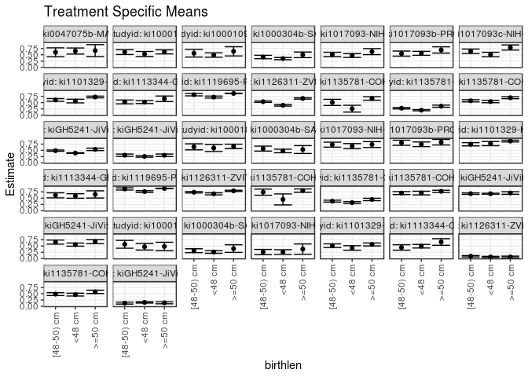

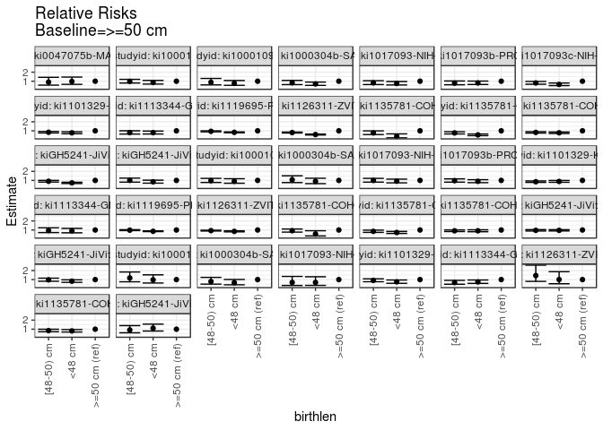

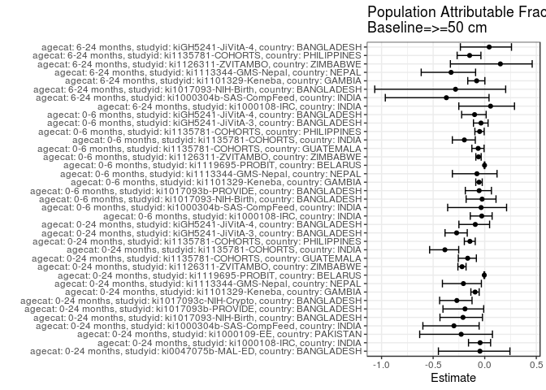

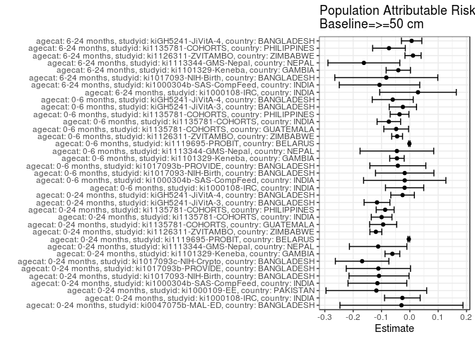

## Results Table

### Parameter: TSM

| agecat | studyid | country | intervention_level | baseline_level | estimate | ci_lower | ci_upper |
| --- | --- | --- | --- | --- | --- | --- | --- |
| 0-24 months | ki0047075b-MAL-ED | BANGLADESH | >=50 cm | NA | 0.6666667 | 0.4286826 | 0.9046507 |
| 0-24 months | ki0047075b-MAL-ED | BANGLADESH | <48 cm | NA | 0.6500000 | 0.5293253 | 0.7706747 |
| 0-24 months | ki0047075b-MAL-ED | BANGLADESH | [48-50) cm | NA | 0.6000000 | 0.4226014 | 0.7773986 |
| 0-24 months | ki1000108-IRC | INDIA | >=50 cm | NA | 0.6154636 | 0.5343827 | 0.6965444 |
| 0-24 months | ki1000108-IRC | INDIA | <48 cm | NA | 0.5316601 | 0.4296037 | 0.6337164 |
| 0-24 months | ki1000108-IRC | INDIA | [48-50) cm | NA | 0.6057837 | 0.5110483 | 0.7005190 |
| 0-24 months | ki1000109-EE | PAKISTAN | >=50 cm | NA | 0.6363636 | 0.4530706 | 0.8196567 |
| 0-24 months | ki1000109-EE | PAKISTAN | <48 cm | NA | 0.4904459 | 0.4037290 | 0.5771627 |
| 0-24 months | ki1000109-EE | PAKISTAN | [48-50) cm | NA | 0.5609756 | 0.4092507 | 0.7127005 |
| 0-24 months | ki1000304b-SAS-CompFeed | INDIA | >=50 cm | NA | 0.4976049 | 0.3864421 | 0.6087677 |
| 0-24 months | ki1000304b-SAS-CompFeed | INDIA | <48 cm | NA | 0.3483104 | 0.3043602 | 0.3922606 |
| 0-24 months | ki1000304b-SAS-CompFeed | INDIA | [48-50) cm | NA | 0.4112123 | 0.3434454 | 0.4789792 |
| 0-24 months | ki1017093-NIH-Birth | BANGLADESH | >=50 cm | NA | 0.6259839 | 0.5064106 | 0.7455571 |
| 0-24 months | ki1017093-NIH-Birth | BANGLADESH | <48 cm | NA | 0.4709597 | 0.3949066 | 0.5470129 |
| 0-24 months | ki1017093-NIH-Birth | BANGLADESH | [48-50) cm | NA | 0.5127875 | 0.4256205 | 0.5999544 |
| 0-24 months | ki1017093b-PROVIDE | BANGLADESH | >=50 cm | NA | 0.6922019 | 0.5670674 | 0.8173364 |
| 0-24 months | ki1017093b-PROVIDE | BANGLADESH | <48 cm | NA | 0.5590573 | 0.4788765 | 0.6392381 |
| 0-24 months | ki1017093b-PROVIDE | BANGLADESH | [48-50) cm | NA | 0.5475421 | 0.4462830 | 0.6488011 |
| 0-24 months | ki1017093c-NIH-Crypto | BANGLADESH | >=50 cm | NA | 0.7909337 | 0.6888051 | 0.8930623 |
| 0-24 months | ki1017093c-NIH-Crypto | BANGLADESH | <48 cm | NA | 0.5100134 | 0.4197546 | 0.6002723 |
| 0-24 months | ki1017093c-NIH-Crypto | BANGLADESH | [48-50) cm | NA | 0.6401304 | 0.5520248 | 0.7282361 |
| 0-24 months | ki1101329-Keneba | GAMBIA | >=50 cm | NA | 0.7219887 | 0.6868459 | 0.7571315 |
| 0-24 months | ki1101329-Keneba | GAMBIA | <48 cm | NA | 0.5622511 | 0.4894026 | 0.6350996 |
| 0-24 months | ki1101329-Keneba | GAMBIA | [48-50) cm | NA | 0.6066698 | 0.5535534 | 0.6597862 |
| 0-24 months | ki1113344-GMS-Nepal | NEPAL | >=50 cm | NA | 0.6531679 | 0.5437512 | 0.7625846 |
| 0-24 months | ki1113344-GMS-Nepal | NEPAL | <48 cm | NA | 0.5188120 | 0.4607605 | 0.5768636 |
| 0-24 months | ki1113344-GMS-Nepal | NEPAL | [48-50) cm | NA | 0.5249141 | 0.4484696 | 0.6013586 |
| 0-24 months | ki1119695-PROBIT | BELARUS | >=50 cm | NA | 0.8648064 | 0.8544839 | 0.8751288 |
| 0-24 months | ki1119695-PROBIT | BELARUS | <48 cm | NA | 0.7200000 | 0.6794039 | 0.7605961 |
| 0-24 months | ki1119695-PROBIT | BELARUS | [48-50) cm | NA | 0.8152610 | 0.7681659 | 0.8623562 |

[output cut: 81 more lines]

### Parameter: E(Y)

| agecat | studyid | country | intervention_level | baseline_level | estimate | ci_lower | ci_upper |
| --- | --- | --- | --- | --- | --- | --- | --- |
| 0-24 months | ki0047075b-MAL-ED | BANGLADESH | NA | NA | 0.6371681 | 0.5446961 | 0.7296402 |
| 0-24 months | ki1000108-IRC | INDIA | NA | NA | 0.5891473 | 0.5364145 | 0.6418800 |
| 0-24 months | ki1000109-EE | PAKISTAN | NA | NA | 0.5181818 | 0.4466550 | 0.5897087 |
| 0-24 months | ki1000304b-SAS-CompFeed | INDIA | NA | NA | 0.3831891 | 0.3479331 | 0.4184451 |
| 0-24 months | ki1017093-NIH-Birth | BANGLADESH | NA | NA | 0.5171569 | 0.4657250 | 0.5685888 |
| 0-24 months | ki1017093b-PROVIDE | BANGLADESH | NA | NA | 0.5811688 | 0.5245443 | 0.6377934 |
| 0-24 months | ki1017093c-NIH-Crypto | BANGLADESH | NA | NA | 0.6225806 | 0.5684562 | 0.6767051 |
| 0-24 months | ki1101329-Keneba | GAMBIA | NA | NA | 0.6604082 | 0.6324757 | 0.6883406 |
| 0-24 months | ki1113344-GMS-Nepal | NEPAL | NA | NA | 0.5413417 | 0.4990070 | 0.5836763 |
| 0-24 months | ki1119695-PROBIT | BELARUS | NA | NA | 0.8612051 | 0.8511051 | 0.8713052 |
| 0-24 months | ki1126311-ZVITAMBO | ZIMBABWE | NA | NA | 0.5452017 | 0.5287719 | 0.5616314 |
| 0-24 months | ki1135781-COHORTS | GUATEMALA | NA | NA | 0.5694915 | 0.5120418 | 0.6269413 |
| 0-24 months | ki1135781-COHORTS | INDIA | NA | NA | 0.2579095 | 0.2406335 | 0.2751855 |
| 0-24 months | ki1135781-COHORTS | PHILIPPINES | NA | NA | 0.6067616 | 0.5822457 | 0.6312775 |
| 0-24 months | kiGH5241-JiVitA-3 | BANGLADESH | NA | NA | 0.4251535 | 0.4129986 | 0.4373083 |
| 0-24 months | kiGH5241-JiVitA-4 | BANGLADESH | NA | NA | 0.2796610 | 0.2580570 | 0.3012650 |
| 0-6 months | ki1000108-IRC | INDIA | NA | NA | 0.6398305 | 0.5770134 | 0.7026476 |
| 0-6 months | ki1000304b-SAS-CompFeed | INDIA | NA | NA | 0.5147059 | 0.4610948 | 0.5683169 |
| 0-6 months | ki1017093-NIH-Birth | BANGLADESH | NA | NA | 0.7142857 | 0.6541352 | 0.7744362 |
| 0-6 months | ki1017093b-PROVIDE | BANGLADESH | NA | NA | 0.7837838 | 0.7252863 | 0.8422812 |
| 0-6 months | ki1101329-Keneba | GAMBIA | NA | NA | 0.8259325 | 0.7956783 | 0.8561867 |
| 0-6 months | ki1113344-GMS-Nepal | NEPAL | NA | NA | 0.6045627 | 0.5449300 | 0.6641955 |
| 0-6 months | ki1119695-PROBIT | BELARUS | NA | NA | 0.8855266 | 0.8758983 | 0.8951550 |
| 0-6 months | ki1126311-ZVITAMBO | ZIMBABWE | NA | NA | 0.7472178 | 0.7302477 | 0.7641880 |
| 0-6 months | ki1135781-COHORTS | GUATEMALA | NA | NA | 0.7547170 | 0.6968087 | 0.8126253 |
| 0-6 months | ki1135781-COHORTS | INDIA | NA | NA | 0.3748545 | 0.3519572 | 0.3977518 |
| 0-6 months | ki1135781-COHORTS | PHILIPPINES | NA | NA | 0.7363515 | 0.7047428 | 0.7679603 |
| 0-6 months | kiGH5241-JiVitA-3 | BANGLADESH | NA | NA | 0.6818985 | 0.6673935 | 0.6964035 |
| 0-6 months | kiGH5241-JiVitA-4 | BANGLADESH | NA | NA | 0.6130952 | 0.5705324 | 0.6556580 |
| 6-24 months | ki1000108-IRC | INDIA | NA | NA | 0.5099338 | 0.4248374 | 0.5950302 |
| 6-24 months | ki1000304b-SAS-CompFeed | INDIA | NA | NA | 0.2878465 | 0.2457514 | 0.3299415 |
| 6-24 months | ki1017093-NIH-Birth | BANGLADESH | NA | NA | 0.2931937 | 0.2273732 | 0.3590142 |
| 6-24 months | ki1101329-Keneba | GAMBIA | NA | NA | 0.5196375 | 0.4788178 | 0.5604571 |
| 6-24 months | ki1113344-GMS-Nepal | NEPAL | NA | NA | 0.4973545 | 0.4426760 | 0.5520330 |
| 6-24 months | ki1126311-ZVITAMBO | ZIMBABWE | NA | NA | 0.0741427 | 0.0585455 | 0.0897399 |
| 6-24 months | ki1135781-COHORTS | PHILIPPINES | NA | NA | 0.5026738 | 0.4688037 | 0.5365439 |
| 6-24 months | kiGH5241-JiVitA-4 | BANGLADESH | NA | NA | 0.1469194 | 0.1276367 | 0.1662021 |

### Parameter: RR

| agecat | studyid | country | intervention_level | baseline_level | estimate | ci_lower | ci_upper |
| --- | --- | --- | --- | --- | --- | --- | --- |
| 0-24 months | ki0047075b-MAL-ED | BANGLADESH | >=50 cm | >=50 cm | 1.0000000 | 1.0000000 | 1.0000000 |
| 0-24 months | ki0047075b-MAL-ED | BANGLADESH | <48 cm | >=50 cm | 0.9750000 | 0.6519879 | 1.4580409 |
| 0-24 months | ki0047075b-MAL-ED | BANGLADESH | [48-50) cm | >=50 cm | 0.9000000 | 0.5660784 | 1.4308972 |
| 0-24 months | ki1000108-IRC | INDIA | >=50 cm | >=50 cm | 1.0000000 | 1.0000000 | 1.0000000 |
| 0-24 months | ki1000108-IRC | INDIA | <48 cm | >=50 cm | 0.8638368 | 0.6842949 | 1.0904859 |
| 0-24 months | ki1000108-IRC | INDIA | [48-50) cm | >=50 cm | 0.9842722 | 0.8020011 | 1.2079680 |
| 0-24 months | ki1000109-EE | PAKISTAN | >=50 cm | >=50 cm | 1.0000000 | 1.0000000 | 1.0000000 |
| 0-24 months | ki1000109-EE | PAKISTAN | <48 cm | >=50 cm | 0.7707006 | 0.5499261 | 1.0801077 |
| 0-24 months | ki1000109-EE | PAKISTAN | [48-50) cm | >=50 cm | 0.8815331 | 0.5935933 | 1.3091465 |
| 0-24 months | ki1000304b-SAS-CompFeed | INDIA | >=50 cm | >=50 cm | 1.0000000 | 1.0000000 | 1.0000000 |
| 0-24 months | ki1000304b-SAS-CompFeed | INDIA | <48 cm | >=50 cm | 0.6999739 | 0.5417291 | 0.9044436 |
| 0-24 months | ki1000304b-SAS-CompFeed | INDIA | [48-50) cm | >=50 cm | 0.8263831 | 0.6263030 | 1.0903812 |
| 0-24 months | ki1017093-NIH-Birth | BANGLADESH | >=50 cm | >=50 cm | 1.0000000 | 1.0000000 | 1.0000000 |
| 0-24 months | ki1017093-NIH-Birth | BANGLADESH | <48 cm | >=50 cm | 0.7523512 | 0.5854771 | 0.9667883 |
| 0-24 months | ki1017093-NIH-Birth | BANGLADESH | [48-50) cm | >=50 cm | 0.8191704 | 0.6339055 | 1.0585807 |
| 0-24 months | ki1017093b-PROVIDE | BANGLADESH | >=50 cm | >=50 cm | 1.0000000 | 1.0000000 | 1.0000000 |
| 0-24 months | ki1017093b-PROVIDE | BANGLADESH | <48 cm | >=50 cm | 0.8076507 | 0.6409972 | 1.0176324 |
| 0-24 months | ki1017093b-PROVIDE | BANGLADESH | [48-50) cm | >=50 cm | 0.7910150 | 0.6101414 | 1.0255078 |
| 0-24 months | ki1017093c-NIH-Crypto | BANGLADESH | >=50 cm | >=50 cm | 1.0000000 | 1.0000000 | 1.0000000 |
| 0-24 months | ki1017093c-NIH-Crypto | BANGLADESH | <48 cm | >=50 cm | 0.6448245 | 0.5178568 | 0.8029219 |
| 0-24 months | ki1017093c-NIH-Crypto | BANGLADESH | [48-50) cm | >=50 cm | 0.8093351 | 0.6699171 | 0.9777677 |
| 0-24 months | ki1101329-Keneba | GAMBIA | >=50 cm | >=50 cm | 1.0000000 | 1.0000000 | 1.0000000 |
| 0-24 months | ki1101329-Keneba | GAMBIA | <48 cm | >=50 cm | 0.7787533 | 0.6783020 | 0.8940807 |
| 0-24 months | ki1101329-Keneba | GAMBIA | [48-50) cm | >=50 cm | 0.8402760 | 0.7602002 | 0.9287866 |
| 0-24 months | ki1113344-GMS-Nepal | NEPAL | >=50 cm | >=50 cm | 1.0000000 | 1.0000000 | 1.0000000 |
| 0-24 months | ki1113344-GMS-Nepal | NEPAL | <48 cm | >=50 cm | 0.7943011 | 0.6495211 | 0.9713530 |
| 0-24 months | ki1113344-GMS-Nepal | NEPAL | [48-50) cm | >=50 cm | 0.8036434 | 0.6437931 | 1.0031837 |
| 0-24 months | ki1119695-PROBIT | BELARUS | >=50 cm | >=50 cm | 1.0000000 | 1.0000000 | 1.0000000 |
| 0-24 months | ki1119695-PROBIT | BELARUS | <48 cm | >=50 cm | 0.8325563 | 0.7859301 | 0.8819487 |
| 0-24 months | ki1119695-PROBIT | BELARUS | [48-50) cm | >=50 cm | 0.9427094 | 0.8887094 | 0.9999905 |

[output cut: 81 more lines]

### Parameter: PAR

| agecat | studyid | country | intervention_level | baseline_level | estimate | ci_lower | ci_upper |
| --- | --- | --- | --- | --- | --- | --- | --- |
| 0-24 months | ki0047075b-MAL-ED | BANGLADESH | >=50 cm | NA | -0.0294985 | -0.2465936 | 0.1875965 |
| 0-24 months | ki1000108-IRC | INDIA | >=50 cm | NA | -0.0263163 | -0.0892079 | 0.0365753 |
| 0-24 months | ki1000109-EE | PAKISTAN | >=50 cm | NA | -0.1181818 | -0.2958163 | 0.0594526 |
| 0-24 months | ki1000304b-SAS-CompFeed | INDIA | >=50 cm | NA | -0.1144158 | -0.2181028 | -0.0107288 |
| 0-24 months | ki1017093-NIH-Birth | BANGLADESH | >=50 cm | NA | -0.1088270 | -0.2147359 | -0.0029181 |
| 0-24 months | ki1017093b-PROVIDE | BANGLADESH | >=50 cm | NA | -0.1110330 | -0.2244171 | 0.0023510 |
| 0-24 months | ki1017093c-NIH-Crypto | BANGLADESH | >=50 cm | NA | -0.1683531 | -0.2627826 | -0.0739235 |
| 0-24 months | ki1101329-Keneba | GAMBIA | >=50 cm | NA | -0.0615805 | -0.0876579 | -0.0355032 |
| 0-24 months | ki1113344-GMS-Nepal | NEPAL | >=50 cm | NA | -0.1118262 | -0.2131720 | -0.0104805 |
| 0-24 months | ki1119695-PROBIT | BELARUS | >=50 cm | NA | -0.0036012 | -0.0065370 | -0.0006654 |
| 0-24 months | ki1126311-ZVITAMBO | ZIMBABWE | >=50 cm | NA | -0.1198593 | -0.1408631 | -0.0988556 |
| 0-24 months | ki1135781-COHORTS | GUATEMALA | >=50 cm | NA | -0.0941040 | -0.1418641 | -0.0463438 |
| 0-24 months | ki1135781-COHORTS | INDIA | >=50 cm | NA | -0.0995641 | -0.1360431 | -0.0630852 |
| 0-24 months | ki1135781-COHORTS | PHILIPPINES | >=50 cm | NA | -0.0870914 | -0.1187189 | -0.0554639 |
| 0-24 months | kiGH5241-JiVitA-3 | BANGLADESH | >=50 cm | NA | -0.1158626 | -0.1614264 | -0.0702987 |
| 0-24 months | kiGH5241-JiVitA-4 | BANGLADESH | >=50 cm | NA | -0.0255925 | -0.0671943 | 0.0160093 |
| 0-6 months | ki1000108-IRC | INDIA | >=50 cm | NA | -0.0184002 | -0.0858624 | 0.0490620 |
| 0-6 months | ki1000304b-SAS-CompFeed | INDIA | >=50 cm | NA | -0.0180072 | -0.1632260 | 0.1272116 |
| 0-6 months | ki1017093-NIH-Birth | BANGLADESH | >=50 cm | NA | -0.0180956 | -0.1211336 | 0.0849424 |
| 0-6 months | ki1017093b-PROVIDE | BANGLADESH | >=50 cm | NA | -0.0423032 | -0.1410844 | 0.0564780 |
| 0-6 months | ki1101329-Keneba | GAMBIA | >=50 cm | NA | -0.0454853 | -0.0709682 | -0.0200024 |
| 0-6 months | ki1113344-GMS-Nepal | NEPAL | >=50 cm | NA | -0.0456595 | -0.1756308 | 0.0843117 |
| 0-6 months | ki1119695-PROBIT | BELARUS | >=50 cm | NA | -0.0015381 | -0.0041179 | 0.0010418 |
| 0-6 months | ki1126311-ZVITAMBO | ZIMBABWE | >=50 cm | NA | -0.0448483 | -0.0639900 | -0.0257066 |
| 0-6 months | ki1135781-COHORTS | GUATEMALA | >=50 cm | NA | -0.0480999 | -0.0918402 | -0.0043596 |
| 0-6 months | ki1135781-COHORTS | INDIA | >=50 cm | NA | -0.0740323 | -0.1155552 | -0.0325094 |
| 0-6 months | ki1135781-COHORTS | PHILIPPINES | >=50 cm | NA | -0.0363661 | -0.0694469 | -0.0032852 |
| 0-6 months | kiGH5241-JiVitA-3 | BANGLADESH | >=50 cm | NA | -0.0245486 | -0.0727533 | 0.0236560 |
| 0-6 months | kiGH5241-JiVitA-4 | BANGLADESH | >=50 cm | NA | -0.0603171 | -0.1326618 | 0.0120276 |
| 6-24 months | ki1000108-IRC | INDIA | >=50 cm | NA | 0.0288218 | -0.1063940 | 0.1640377 |
| 6-24 months | ki1000304b-SAS-CompFeed | INDIA | >=50 cm | NA | -0.1070159 | -0.2490043 | 0.0349726 |
| 6-24 months | ki1017093-NIH-Birth | BANGLADESH | >=50 cm | NA | -0.0830227 | -0.2648169 | 0.0987715 |
| 6-24 months | ki1101329-Keneba | GAMBIA | >=50 cm | NA | -0.0407010 | -0.0836108 | 0.0022088 |
| 6-24 months | ki1113344-GMS-Nepal | NEPAL | >=50 cm | NA | -0.1622102 | -0.2890377 | -0.0353827 |
| 6-24 months | ki1126311-ZVITAMBO | ZIMBABWE | >=50 cm | NA | 0.0112485 | -0.0172231 | 0.0397202 |
| 6-24 months | ki1135781-COHORTS | PHILIPPINES | >=50 cm | NA | -0.0736075 | -0.1312807 | -0.0159342 |
| 6-24 months | kiGH5241-JiVitA-4 | BANGLADESH | >=50 cm | NA | 0.0063513 | -0.0296394 | 0.0423420 |

### Parameter: PAF

| agecat | studyid | country | intervention_level | baseline_level | estimate | ci_lower | ci_upper |
| --- | --- | --- | --- | --- | --- | --- | --- |
| 0-24 months | ki0047075b-MAL-ED | BANGLADESH | >=50 cm | NA | -0.0462963 | -0.4489074 | 0.2444404 |
| 0-24 months | ki1000108-IRC | INDIA | >=50 cm | NA | -0.0446684 | -0.1572544 | 0.0569644 |
| 0-24 months | ki1000109-EE | PAKISTAN | >=50 cm | NA | -0.2280702 | -0.6304066 | 0.0749814 |
| 0-24 months | ki1000304b-SAS-CompFeed | INDIA | >=50 cm | NA | -0.2985883 | -0.5994709 | -0.0543059 |
| 0-24 months | ki1017093-NIH-Birth | BANGLADESH | >=50 cm | NA | -0.2104333 | -0.4338425 | -0.0218338 |
| 0-24 months | ki1017093b-PROVIDE | BANGLADESH | >=50 cm | NA | -0.1910513 | -0.4047658 | -0.0098502 |
| 0-24 months | ki1017093c-NIH-Crypto | BANGLADESH | >=50 cm | NA | -0.2704117 | -0.4371527 | -0.1230162 |
| 0-24 months | ki1101329-Keneba | GAMBIA | >=50 cm | NA | -0.0932462 | -0.1342830 | -0.0536940 |
| 0-24 months | ki1113344-GMS-Nepal | NEPAL | >=50 cm | NA | -0.2065724 | -0.4101022 | -0.0324194 |
| 0-24 months | ki1119695-PROBIT | BELARUS | >=50 cm | NA | -0.0041816 | -0.0076001 | -0.0007747 |
| 0-24 months | ki1126311-ZVITAMBO | ZIMBABWE | >=50 cm | NA | -0.2198440 | -0.2599752 | -0.1809911 |
| 0-24 months | ki1135781-COHORTS | GUATEMALA | >=50 cm | NA | -0.1652421 | -0.2560638 | -0.0809874 |
| 0-24 months | ki1135781-COHORTS | INDIA | >=50 cm | NA | -0.3860430 | -0.5340349 | -0.2523281 |
| 0-24 months | ki1135781-COHORTS | PHILIPPINES | >=50 cm | NA | -0.1435348 | -0.1976126 | -0.0918989 |
| 0-24 months | kiGH5241-JiVitA-3 | BANGLADESH | >=50 cm | NA | -0.2725194 | -0.3846673 | -0.1694545 |
| 0-24 months | kiGH5241-JiVitA-4 | BANGLADESH | >=50 cm | NA | -0.0915126 | -0.2503667 | 0.0471597 |
| 0-6 months | ki1000108-IRC | INDIA | >=50 cm | NA | -0.0287579 | -0.1400303 | 0.0716538 |
| 0-6 months | ki1000304b-SAS-CompFeed | INDIA | >=50 cm | NA | -0.0349854 | -0.3592662 | 0.2119315 |
| 0-6 months | ki1017093-NIH-Birth | BANGLADESH | >=50 cm | NA | -0.0253338 | -0.1803714 | 0.1093402 |
| 0-6 months | ki1017093b-PROVIDE | BANGLADESH | >=50 cm | NA | -0.0539730 | -0.1881476 | 0.0650496 |
| 0-6 months | ki1101329-Keneba | GAMBIA | >=50 cm | NA | -0.0550715 | -0.0868249 | -0.0242458 |
| 0-6 months | ki1113344-GMS-Nepal | NEPAL | >=50 cm | NA | -0.0755249 | -0.3135208 | 0.1193487 |
| 0-6 months | ki1119695-PROBIT | BELARUS | >=50 cm | NA | -0.0017369 | -0.0046554 | 0.0011731 |
| 0-6 months | ki1126311-ZVITAMBO | ZIMBABWE | >=50 cm | NA | -0.0600204 | -0.0861454 | -0.0345237 |
| 0-6 months | ki1135781-COHORTS | GUATEMALA | >=50 cm | NA | -0.0637324 | -0.1245591 | -0.0061958 |
| 0-6 months | ki1135781-COHORTS | INDIA | >=50 cm | NA | -0.1974961 | -0.3139097 | -0.0913969 |
| 0-6 months | ki1135781-COHORTS | PHILIPPINES | >=50 cm | NA | -0.0493868 | -0.0955056 | -0.0052095 |
| 0-6 months | kiGH5241-JiVitA-3 | BANGLADESH | >=50 cm | NA | -0.0360004 | -0.1091812 | 0.0323521 |
| 0-6 months | kiGH5241-JiVitA-4 | BANGLADESH | >=50 cm | NA | -0.0983813 | -0.2234834 | 0.0139291 |
| 6-24 months | ki1000108-IRC | INDIA | >=50 cm | NA | 0.0565207 | -0.2511943 | 0.2885572 |
| 6-24 months | ki1000304b-SAS-CompFeed | INDIA | >=50 cm | NA | -0.3717810 | -0.9636714 | 0.0417016 |
| 6-24 months | ki1017093-NIH-Birth | BANGLADESH | >=50 cm | NA | -0.2831668 | -1.0660702 | 0.2030682 |
| 6-24 months | ki1101329-Keneba | GAMBIA | >=50 cm | NA | -0.0783258 | -0.1644944 | 0.0014667 |
| 6-24 months | ki1113344-GMS-Nepal | NEPAL | >=50 cm | NA | -0.3261460 | -0.6157091 | -0.0884777 |
| 6-24 months | ki1126311-ZVITAMBO | ZIMBABWE | >=50 cm | NA | 0.1517146 | -0.3328120 | 0.4600978 |
| 6-24 months | ki1135781-COHORTS | PHILIPPINES | >=50 cm | NA | -0.1464319 | -0.2674680 | -0.0369540 |
| 6-24 months | kiGH5241-JiVitA-4 | BANGLADESH | >=50 cm | NA | 0.0432298 | -0.2360935 | 0.2594338 |